# Tanks to Turbines

Innovation Strategy Explorer — insights

2026-05-07

## How knowledge travels: green technology

Forward citations radiating out from the **top 1,000 green-tech innovations worldwide** (ranked by Average Global Spillover, `ev_global`). `gen 0` (blue) are the source patents; `gen 1` (red) is direct citations; `gen 2-4` (green / orange / purple) are citations of citations. Edges are a 1% random sample at each step so the map stays legible. Knowledge fans out across every continent.

Open the live HiGGlobe view →

[interactive chart not shown]

## Contrast: defence technology

Same construction, same parameters — top 1,000 defence-tech innovations worldwide, four generations of forward citations, 1% edge sample.

Open the live HiGGlobe view →

[interactive chart not shown]

Defence citations stay closer to their home cluster, fade to `gen 1` / `gen 2`, and rarely reach the deeper generations — even though the gen 0 seeds are the top 1,000 defence patents the database knows about.

## For comparison: AI technology

The same construction applied to the **top 1,000 AI patents worldwide** — where the spillover-driven justification for public investment is arguably even louder than for defence. AI’s citation network is denser than green’s at every generation, but is overwhelmingly concentrated in a narrower band of countries (US west coast, China east coast, Korea, Western Europe).

Open the live HiGGlobe view →

[interactive chart not shown]

## The headline number: four umbrellas, three origins

Per-innovation **Average Global Spillover** (`ev_global`) for the four top-level technology umbrellas, full database (granted *and* non-granted families), side-by-side for each origin economy.

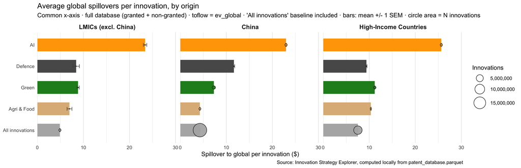

Open this view in the live Country Explorer →

## A closer look: subcategories of green vs defence

The umbrella averages mask substantial within-family variation. Below, every subcategory of both umbrellas in a single facetted panel — bar length is per-innovation `ev_global`, circle size is the count of innovations behind the average, dashed lines are family means within each origin.

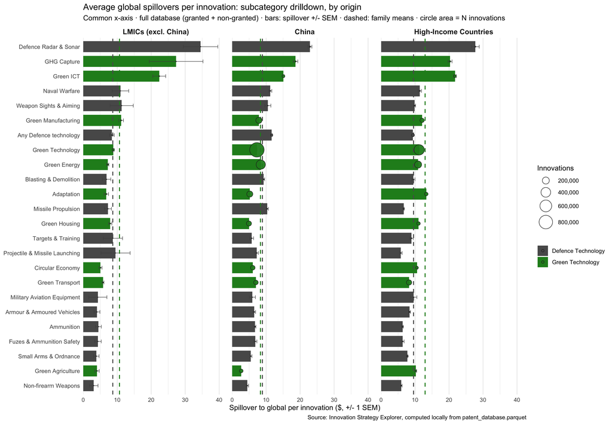